# Nonlinear models - polynomial, spline, GAM

Tarek El-Hajjaoui

2023-05-21

## ISLR2 Chapter 7: Questions 9 & 10

```r
library(caret) # trainControl( ), train( ) used for cross validation
library(splines) # bs() used to create matrix of basis functions for splines
library(leaps) # Forward stepwise selection
library(mgcv)
library(ggplot2)
```

### ISLR2 Chapter 7: Question 9

This question uses the variables dis (the weighted mean of distances to five Boston employment centers) and nox (nitrogen oxides concentration in parts per 10 million) from the Boston data. We will treat dis as the predictor and nox as the response.

Preprocessing Boston dataset

```r
file_path = '/Users/Tarek/Documents/UCI_MDS_Coding/Stats211P/R_Statistical_Modeling/ISLRv2_Datasets/Boston.csv'
df_boston <- read.csv(file_path, row.names = NULL, header = TRUE)
# keep only the 'dis' and 'nox' columns
df_boston <- df_boston[, c("dis", "nox")]
df_boston <- na.omit(df_boston) # drop na rows
# drop column X from the dataframe
df_boston$X <- NULL
```

```r
head(df_boston)
```

```
##      dis   nox
## 1 4.0900 0.538
## 2 4.9671 0.469
## 3 4.9671 0.469
## 4 6.0622 0.458
## 5 6.0622 0.458
## 6 6.0622 0.458
```

```r
str(df_boston) # ensure data types correct now
```

```
## 'data.frame':    506 obs. of  2 variables:
##  $ dis: num  4.09 4.97 4.97 6.06 6.06 ...
##  $ nox: num  0.538 0.469 0.469 0.458 0.458 0.458 0.524 0.524 0.524 0.524 ...
```

```r
colSums(is.na(df_boston)) # count number of nulls in each column
```

```
## dis nox
##   0   0
```

```r
nrow(df_boston)
```

```
## [1] 506
```

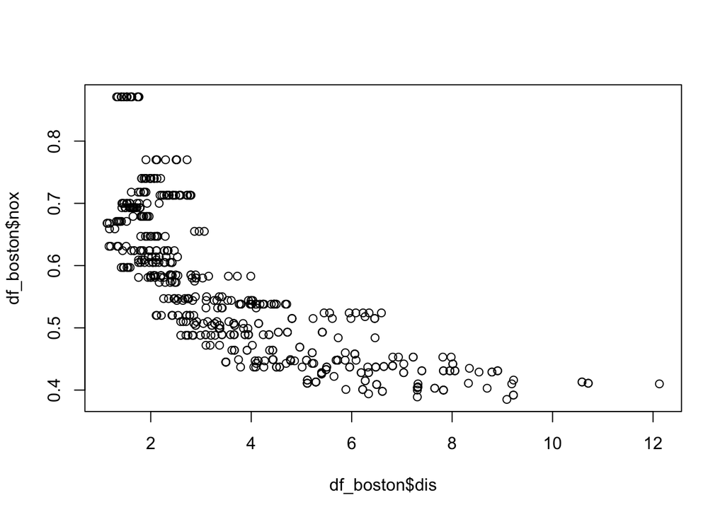

```r
plot(df_boston$dis, df_boston$nox)
```

#### 9 a)

Use the poly() function to fit a cubic polynomial regression to predict nox using dis. Report the regression output, and plot the resulting data and polynomial fits.

```r
cubic_fit <- lm(nox ~ poly(dis, 3), data = df_boston)
```

Report the regression output

```r
# columns are a basis of orthogonal polynomials,
# which means that each column is a linear combination
# of the variables dis, dis^2, dis^3 and dis^4
summary(cubic_fit)
```

```
##
## Call:
## lm(formula = nox ~ poly(dis, 3), data = df_boston)
##
## Residuals:
##       Min        1Q    Median        3Q       Max
## -0.121130 -0.040619 -0.009738  0.023385  0.194904
##
## Coefficients:
##                Estimate Std. Error t value Pr(>|t|)
## (Intercept)    0.554695   0.002759 201.021  < 2e-16 ***
## poly(dis, 3)1 -2.003096   0.062071 -32.271  < 2e-16 ***
## poly(dis, 3)2  0.856330   0.062071  13.796  < 2e-16 ***
## poly(dis, 3)3 -0.318049   0.062071  -5.124 4.27e-07 ***
## ---
## Signif. codes:  0 '***' 0.001 '**' 0.01 '*' 0.05 '.' 0.1 ' ' 1
##
## Residual standard error: 0.06207 on 502 degrees of freedom
## Multiple R-squared:  0.7148, Adjusted R-squared:  0.7131
## F-statistic: 419.3 on 3 and 502 DF,  p-value: < 2.2e-16
```

Plot the resulting data and polynomial fits

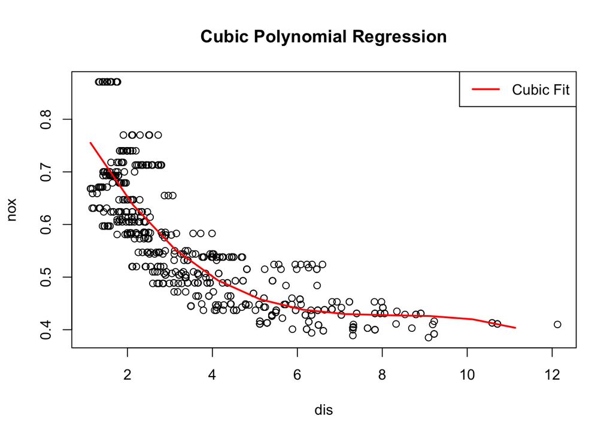

```r
dislims <- range(df_boston$dis)

# grid of values for dis at which we want predictions
dis.grid <- seq(from = dislims[1], to = dislims[2])

nox_pred <- predict(cubic_fit, newdata = list(dis = dis.grid), se = TRUE)

plot(df_boston$dis, df_boston$nox, xlab = "dis", ylab = "nox", main = "Cubic Polynomial Regression")
lines(dis.grid, nox_pred$fit, col = "red", lwd = 2)
legend("topright", legend = "Cubic Fit", col = "red", lwd = 2)
```

#### 9 b)

Plot the polynomial fits for a range of different polynomial degrees (say, from 1 to 10), and report the associated residual sum of squares.

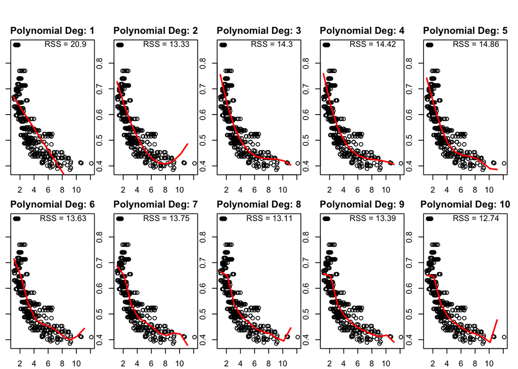

```r
# initialize an empty vector to store the RSS values
rss_values <- numeric(10)

par(mfrow = c(2, 5)) # 2 x 5 plotting matrix

# adjust bottom margin for the plots
par(oma = c(0, 0, 2, 0) + 0.1, mar = c(2, 1, 2, 1))

# iterate over different polynomial degrees
for (degree in 1:10) {
  # fit the polynomial regression model
  fit <- lm(nox ~ poly(dis, degree), data = df_boston)
  # predict the response variable
  nox_pred <- predict(fit, newdata = list(dis = dis.grid), se = TRUE)
  # calculate the residual sum of squares (RSS)
  rss <- sum((df_boston$nox - nox_pred$fit)^2)
  # store the RSS value
  rss_values[degree] <- rss
  # plot the polynomial fit
  plot(df_boston$dis, df_boston$nox, xlab = "dis", ylab = "nox", main = paste("Polynomial Deg:", degree))
  lines(dis.grid, nox_pred$fit, col = "red", lwd = 2)
  text(x = max(df_boston$dis), y = max(df_boston$nox), paste("RSS =", round(rss, 2)),
       pos = 2, offset = 0.5, adj = c(1, 1))
}
```

```r
# associated RSS values
for (degree in 1:10) {
  cat("Degree", degree, ": RSS =", rss_values[degree], "\n")
}
```

```
## Degree 1 : RSS = 20.8994
## Degree 2 : RSS = 13.32777
## Degree 3 : RSS = 14.30233
## Degree 4 : RSS = 14.42078
## Degree 5 : RSS = 14.86415
## Degree 6 : RSS = 13.63421
## Degree 7 : RSS = 13.75387
## Degree 8 : RSS = 13.11053
## Degree 9 : RSS = 13.39082
## Degree 10 : RSS = 12.73548
```

```r
par(mfrow = c(1,1))
```

#### 9 c)

Perform cross-validation or another approach to select the optimal degree for the polynomial, and explain your results.

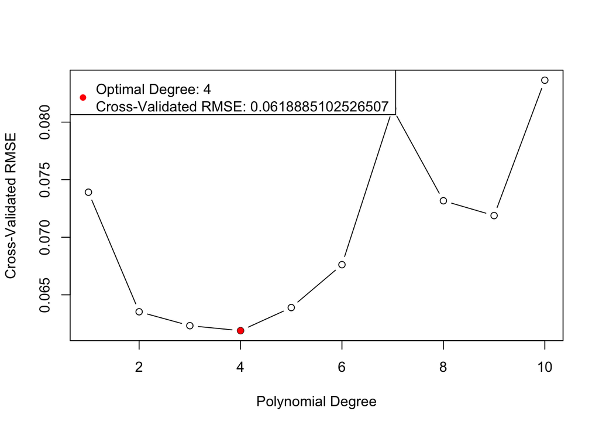

```r
set.seed(0)

# range of polynomial degrees to consider
degree_range <- 1:10

# initialize an empty vector to store the cross-validated MSE values
mse_values <- numeric(length(degree_range))

# perform cross-validation for each degree
for (i in degree_range) {
  # polynomial features for the given degree
  poly_features <- poly(df_boston$dis, i)

  # combine the polynomial features with the response variable
  poly_data <- data.frame(nox = df_boston$nox, poly_features)

  # create a list of seeds for cross-validation
  cv_seeds <- vector("list", 11)
  for (j in 1:10) {
    cv_seeds[[j]] <- sample.int(1000, 1)  # use a different seed for each fold
  }
  cv_seeds[[11]] <- sample.int(1000, 1)  # Additional seed element

  # perform cross-validation using 10-fold cross-validation
  cv <- trainControl(method = "cv", number = 10, seeds = cv_seeds) # from caret library

  # fit the polynomial regression model and evaluate MSE using cross-validation
  fit <- train(nox ~ ., data = poly_data, method = "lm", trControl = cv) # from caret library

  # store the cross-validated MSE value
  mse_values[i] <- fit$results$RMSE
}

# find the optimal degree with the lowest cross-validated MSE
optimal_degree <- which.min(mse_values)

# plot the cross-validated MSE values
plot(degree_range, mse_values, type = "b", xlab = "Polynomial Degree", ylab = "Cross-Validated RMSE")

# Add a point to indicate the optimal degree
points(optimal_degree, mse_values[optimal_degree], col = "red", pch = 16)

# Add a text label for the optimal degree
legend_text <- paste("Optimal Degree:", optimal_degree, "\nCross-Validated RMSE:", mse_values[optimal_degree])
legend("topleft", legend = legend_text, col = "red", pch = 16)
```

```r
# print optimal degree and the associated cross-validated MSE value
cat("Optimal Degree:", optimal_degree, "\n")
```

```
## Optimal Degree: 4
```

```r
cat("Cross-Validated RMSE:", mse_values[optimal_degree], "\n")
```

```
## Cross-Validated RMSE: 0.06188851
```

Polynomial 10-Fold CV Results:

- 10-fold cross validation was performed on different polynomial degrees, ranging from 1 - 10, with the help of the caret library. The train method returns a dataframe of the training error rate for the 10-fold validation. For each ith degree, the root mean squared error (RMSE) is stored. In the graph above the RMSE for each ith degree is plotted. 4th degree has the lowest RMSE so a polynomial degree of 4 is chosen. It should be noted there are different factors that influence the results such as random seeding; however, overall the RMSE for all degrees are relatively close.

#### 9 d)

Use the bs() function to fit a regression spline to predict nox using dis. Report the output for the fit using four degrees of freedom. How did you choose the knots? Plot the resulting fit.

Report the output for the fit using four degrees of freedom

```r
# regression spline with four degrees of freedom
spline_fit <- lm(nox ~ bs(dis, df = 4), data = df_boston)
summary(spline_fit)
```

```
##
## Call:
## lm(formula = nox ~ bs(dis, df = 4), data = df_boston)
##
## Residuals:
##       Min        1Q    Median        3Q       Max
## -0.124622 -0.039259 -0.008514  0.020850  0.193891
##
## Coefficients:
##                  Estimate Std. Error t value Pr(>|t|)
## (Intercept)       0.73447    0.01460  50.306  < 2e-16 ***
## bs(dis, df = 4)1 -0.05810    0.02186  -2.658  0.00812 **
## bs(dis, df = 4)2 -0.46356    0.02366 -19.596  < 2e-16 ***
## bs(dis, df = 4)3 -0.19979    0.04311  -4.634 4.58e-06 ***
## bs(dis, df = 4)4 -0.38881    0.04551  -8.544  < 2e-16 ***
## ---
## Signif. codes:  0 '***' 0.001 '**' 0.01 '*' 0.05 '.' 0.1 ' ' 1
##
## Residual standard error: 0.06195 on 501 degrees of freedom
## Multiple R-squared:  0.7164, Adjusted R-squared:  0.7142
## F-statistic: 316.5 on 4 and 501 DF,  p-value: < 2.2e-16
```

Plot the resulting fit

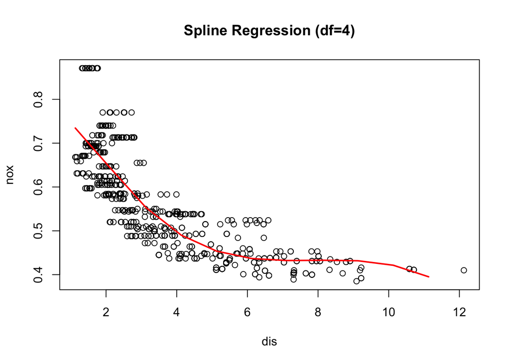

```r
spline_pred <- predict(spline_fit, newdata = list(dis = dis.grid), se = T)
plot(df_boston$dis, df_boston$nox, xlab = "dis", ylab = "nox", main = "Spline Regression (df=4)")
# uncomment below if want to see standard 95% confidence interval
# lines(dis.grid, spline_pred$fit + 2 * spline_pred$se, lty = "dashed", col = "red")
# lines(dis.grid, spline_pred$fit - 2 * spline_pred$se, lty = "dashed", col = "red")
lines(dis.grid, spline_pred$fit, col = "red", lwd = 2)
```

How the knots were chosen?

- The bs() function with df specified determines the placement of knots based on the data. The number of degrees of freedom (df) controls the number and placement of internal knots in the spline, which determines the flexibility of the spline fit.

#### 9 e)

Now fit a regression spline for a range of degrees of freedom, and plot the resulting fits and report the resulting RSS. Describe the results obtained.

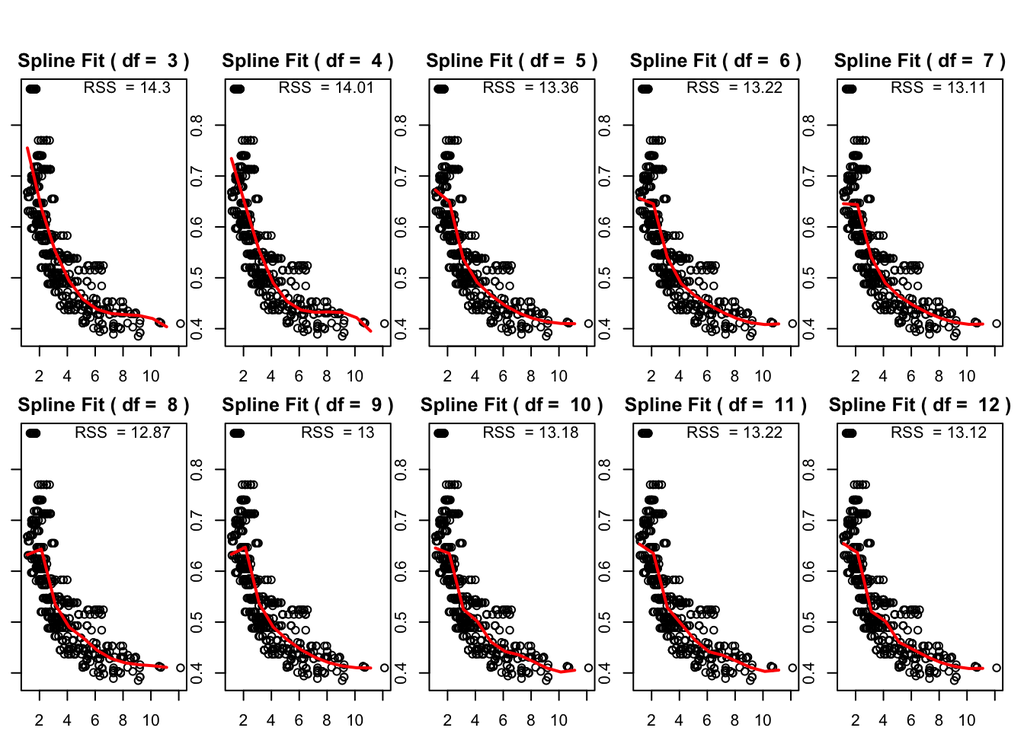

```r
# define the range of degrees of freedom to consider
df_range <- 3:12

# initialize an empty vector to store the RSS values
rss_values <- numeric(length(df_range))

par(mfrow = c(2, 5)) # 2 x 5 plotting matrix

# adjust bottom margin for the plots
par(oma = c(0, 0, 2, 0) + 0.1, mar = c(2, 1, 2, 1))

# iterate over the range of degrees of freedom
for (i in df_range) {
  # fit regression spline with the current degrees of freedom
  spline_fit <- lm(nox ~ bs(dis, df = i), data = df_boston)

  # predict the response variable
  nox_pred <- predict(spline_fit, newdata = list(dis = dis.grid), se = T)

  # calculate the residual sum of squares (RSS)
  rss <- sum((df_boston$nox - nox_pred$fit)^2)

  # store the RSS value
  rss_values[i] <- rss

  # plot the data
  plot(df_boston$dis, df_boston$nox, xlab = "dis", ylab = "nox", main = paste("Spline Fit ( df = ", i, ")"))

  # plot the resulting fit
  lines(dis.grid, nox_pred$fit, col = "red", lwd = 2)

  text(x = max(df_boston$dis), y = max(df_boston$nox), paste("RSS  =", round(rss, 2)),
       pos = 2, offset = 0.5, adj = c(1, 1))
}
```

```r
# print the resulting RSS values
for (i in df_range) {
  cat("Degrees of Freedom:", i, "RSS =", rss_values[i], "\n")
}
```

```
## Degrees of Freedom: 3 RSS = 14.30233
## Degrees of Freedom: 4 RSS = 14.011
## Degrees of Freedom: 5 RSS = 13.36125
## Degrees of Freedom: 6 RSS = 13.21649
## Degrees of Freedom: 7 RSS = 13.10655
## Degrees of Freedom: 8 RSS = 12.87242
## Degrees of Freedom: 9 RSS = 13.0001
## Degrees of Freedom: 10 RSS = 13.17838
## Degrees of Freedom: 11 RSS = 13.21587
## Degrees of Freedom: 12 RSS = 13.12253
```

Spline Degrees of Freedom Results:

- The spline model with 8 degrees of freedom has the lowest residual sum of squares (RSS), which suggests its the optimal df value. In general, higher values of df allow for more flexibility and can result in a better fit to the data. However as the df becomes too high, the model starts to fit the noise and random variations in the training data, leading to overfitting. The model becomes too complex and loses its ability to generalize well to new data, which is why the df values higher than 8 have higher RSS values.

#### 9 f)

Perform cross-validation or another approach in order to select the best degrees of freedom for a regression spline on this data. Describe your results.

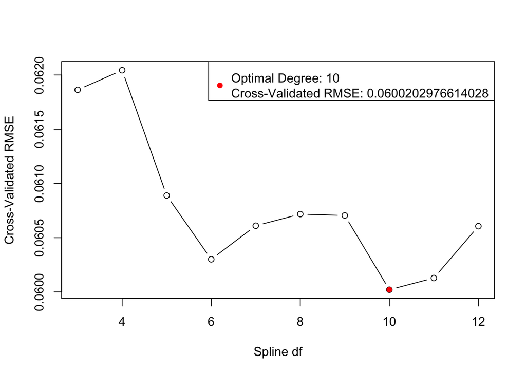

```r
set.seed(0)

# range of polynomial degrees to consider
degree_range <- 3:12
index <- 1

# initialize an empty vector to store the cross-validated MSE values
mse_values <- numeric(length(degree_range))

# perform cross-validation for each degree
for (i in degree_range) {
  # spline features for the given degree
  bs_features <- bs(df_boston$dis, df = i)

  # combine the spline features with the response variable
  spline_data <- data.frame(nox = df_boston$nox, bs_features)

  # create a list of seeds for cross-validation
  cv_seeds <- vector("list", 11)
  for (j in 1:10) {
    cv_seeds[[j]] <- sample.int(1000, 1)  # use a different seed for each fold
  }
  cv_seeds[[11]] <- sample.int(1000, 1)  # Additional seed element

  # perform cross-validation using 10-fold cross-validation
  cv <- trainControl(method = "cv", number = 10, seeds = cv_seeds) # from caret library

  # fit the spline regression model and evaluate MSE using cross-validation
  fit <- train(nox ~ ., data = spline_data, method = "lm", trControl = cv) # from caret library

  # store the cross-validated MSE value
  mse_values[index] <- fit$results$RMSE

  # increment the index
  index <- index + 1
}

# find the optimal degree with the lowest cross-validated MSE
optimal_degree <- degree_range[which.min(mse_values)]

# plot the cross-validated MSE values
plot(degree_range, mse_values, type = "b", xlab = "Spline df", ylab = "Cross-Validated RMSE")

# point to indicate the optimal degree
points(optimal_degree, mse_values[which.min(mse_values)], col = "red", pch = 16)

# text label for the optimal degree
legend_text <- paste("Optimal Degree:", optimal_degree, "\nCross-Validated RMSE:", mse_values[which.min(mse_values)])
legend("topright", legend = legend_text, col = "red", pch = 16)
```

Spline Degrees of Freedom 10-Fold CV Results:

- The results above provide stronger evidence about choosing the optimal df because 10-fold cross validation was performed on different degrees of freedom, ranging from 3 - 12, with the help of the caret library. The train method returns a dataframe of the training error rate for the 10-fold validation. For each ith degree of freedom, the root mean squared error (RMSE) is stored. In the graph above the RMSE for each ith degree is plotted. 10 degrees of freedom has the lowest RMSE but, 6 degrees of freedom has a very comparable RSS value and perhaps would be a better model choice to minimize overfitting effects.

### ISLR2 Chapter 7: Question 10

Loading College dataset and preprocessing

```r
file_path = '/Users/Tarek/Documents/UCI_MDS_Coding/Stats211P/R_Statistical_Modeling/ISLRv2_Datasets/College.csv'
df_college <- read.csv(file_path, row.names = NULL, header = TRUE)
df_college <- na.omit(df_college)
# drop column X from the dataframe
df_college$X <- NULL
```

```r
categorical_cols <- c('Private')
df_college[categorical_cols] <- lapply(df_college[categorical_cols], as.factor)
```

```r
str(df_college) # ensure data types correct now
```

```
## 'data.frame':    777 obs. of  18 variables:
##  $ Private    : Factor w/ 2 levels "No","Yes": 2 2 2 2 2 2 2 2 2 2 ...
##  $ Apps       : int  1660 2186 1428 417 193 587 353 1899 1038 582 ...
##  $ Accept     : int  1232 1924 1097 349 146 479 340 1720 839 498 ...
##  $ Enroll     : int  721 512 336 137 55 158 103 489 227 172 ...
##  $ Top10perc  : int  23 16 22 60 16 38 17 37 30 21 ...
##  $ Top25perc  : int  52 29 50 89 44 62 45 68 63 44 ...
##  $ F.Undergrad: int  2885 2683 1036 510 249 678 416 1594 973 799 ...
##  $ P.Undergrad: int  537 1227 99 63 869 41 230 32 306 78 ...
##  $ Outstate   : int  7440 12280 11250 12960 7560 13500 13290 13868 15595 10468 ...
##  $ Room.Board : int  3300 6450 3750 5450 4120 3335 5720 4826 4400 3380 ...
##  $ Books      : int  450 750 400 450 800 500 500 450 300 660 ...
##  $ Personal   : int  2200 1500 1165 875 1500 675 1500 850 500 1800 ...
##  $ PhD        : int  70 29 53 92 76 67 90 89 79 40 ...
##  $ Terminal   : int  78 30 66 97 72 73 93 100 84 41 ...
##  $ S.F.Ratio  : num  18.1 12.2 12.9 7.7 11.9 9.4 11.5 13.7 11.3 11.5 ...
##  $ perc.alumni: int  12 16 30 37 2 11 26 37 23 15 ...
##  $ Expend     : int  7041 10527 8735 19016 10922 9727 8861 11487 11644 8991 ...
##  $ Grad.Rate  : int  60 56 54 59 15 55 63 73 80 52 ...
```

```r
colSums(is.na(df_college)) # count number of nulls in each column
```

```
##     Private        Apps      Accept      Enroll   Top10perc   Top25perc
##           0           0           0           0           0           0
## F.Undergrad P.Undergrad    Outstate  Room.Board       Books    Personal
##           0           0           0           0           0           0
##         PhD    Terminal   S.F.Ratio perc.alumni      Expend   Grad.Rate
##           0           0           0           0           0           0
```

```r
nrow(df_college)
```

```
## [1] 777
```

#### 10 a)

Split the data into a training set and a test set. Using out-of-state tuition as the response and the other variables as the predictors.

Split the data set into a training set and a test set.

```r
set.seed(0) # set random seed for reproducibility
# split the dataframe into train and test sets
train_indices <- createDataPartition(df_college$Outstate, p = 0.7, list = FALSE)
train_college <- df_college[train_indices, ]
train_y <- data.matrix(subset(train_college, select=c('Outstate')))
train_X <- data.matrix(train_college[,!names(train_college) %in% c("Outstate")])
dim(train_X);dim(train_y) # checking dims of split data
```

```
## [1] 546  17
```

```
## [1] 546   1
```

```r
test_college <- df_college[-train_indices, ]
test_y <- data.matrix(subset(test_college, select=c('Outstate')))
test_X <- data.matrix(test_college[,!names(test_college) %in% c("Outstate")])
dim(test_X);dim(test_y) # checking dims of split data
```

```
## [1] 231  17
```

```
## [1] 231   1
```

Perform forward stepwise selection on the training set in order to identify a satisfactory model that uses just a subset of the predictors.

```r
set.seed(0)
forward_fit <- regsubsets(Outstate ~ ., nvmax = 18, data = train_college, method = "forward")

# find the best model based on BIC (Bayesian Information Criterion)
best_model <- which.min(summary(forward_fit)$bic)

cat("Best model using", best_model, "predictors.\n")
```

```
## Best model using 12 predictors.
```

```r
# get the predictors selected by the best model
selected_predictors <- names(coef(forward_fit, best_model))[-1]

cat("Selected Predictors:\n")
```

```
## Selected Predictors:
```

```r
coef(forward_fit, best_model)
```

```
##   (Intercept)    PrivateYes          Apps        Accept     Top10perc
## -1141.3525265  2219.9253697    -0.2812346     0.6982823    23.3505689
##   F.Undergrad    Room.Board      Personal           PhD     S.F.Ratio
##    -0.1591775     0.9634229    -0.2937403    34.9280226   -61.3102610
##   perc.alumni        Expend     Grad.Rate
##    41.4617271     0.1685989    19.1042178
```

#### 10 b)

Fit a GAM on the training data, using out-of-state tuition as the response and the features selected in the previous step as the predictors. Plot the results, and explain your findings.

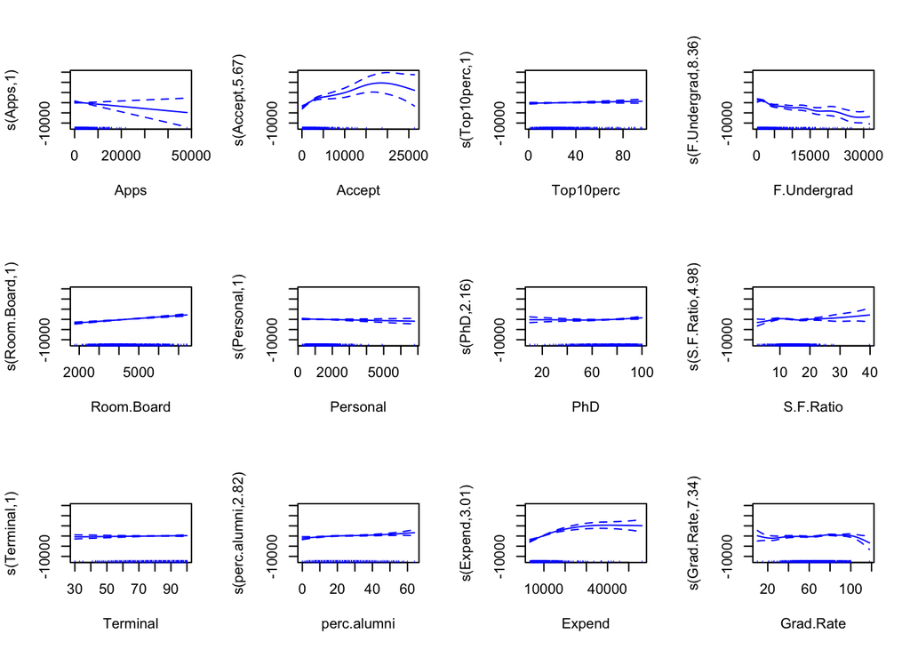

```r
set.seed(0)
# fit a GAM using the selected predictors
gam_fit <- gam(Outstate ~ Private + s(Apps) + s(Accept) + s(Top10perc) + s(F.Undergrad) + s(Room.Board) + s(Personal) + s(PhD) + s(S.F.Ratio) + s(Terminal) + s(perc.alumni) + s(Expend) + s(Grad.Rate),
               data = train_college)
plot(gam_fit, pages = 1, se = TRUE, col = "blue")
```

The solid lines in each of the graphs above represent the estimated effect of a predictor on the response (Outstate). It depicts the relationship between the predictor and the response after adjusting for the effects of all other variables in the model. The two dotted lines represent a 95% confidence interval.

#### 10 c)

Evaluate the model obtained on the test set, and explain the results obtained.

```r
set.seed(0)
# Predict values for the test set
predicted_values <- predict(gam_fit, newdata = test_college)

# Calculate mean squared error (MSE)
mse <- mean((test_college$Outstate - predicted_values)^2)
cat("Test set Mean Squared Error:", mse, "\n")
```

```
## Test set Mean Squared Error: 3444507
```

```r
# Calculate root mean squared error (RMSE)
rmse <- sqrt(mse)
cat("Test set Root Mean Squared Error:", rmse, "\n")
```

```
## Test set Root Mean Squared Error: 1855.938
```

```r
cat("Standard Deviation of Outstate from dataset:", sd(test_college$Outstate), "\n")
```

```
## Standard Deviation of Outstate from dataset: 4151.108
```

#### 10 d)

For which variables, if any, is there evidence of a non-linear relationship with the response?

```r
summary(gam_fit)
```

```
##
## Family: gaussian
## Link function: identity
##
## Formula:
## Outstate ~ Private + s(Apps) + s(Accept) + s(Top10perc) + s(F.Undergrad) +
##     s(Room.Board) + s(Personal) + s(PhD) + s(S.F.Ratio) + s(Terminal) +
##     s(perc.alumni) + s(Expend) + s(Grad.Rate)
##
## Parametric coefficients:
##             Estimate Std. Error t value Pr(>|t|)
## (Intercept)   9095.0      241.4  37.677  < 2e-16 ***
## PrivateYes    1872.7      317.1   5.906 6.45e-09 ***
## ---
## Signif. codes:  0 '***' 0.001 '**' 0.01 '*' 0.05 '.' 0.1 ' ' 1
##
## Approximate significance of smooth terms:
##                  edf Ref.df      F  p-value
## s(Apps)        1.000  1.000  1.879  0.17102
## s(Accept)      5.672  6.878  8.332  < 2e-16 ***
## s(Top10perc)   1.000  1.000  2.091  0.14882
## s(F.Undergrad) 8.359  8.862  5.599 2.39e-07 ***
## s(Room.Board)  1.000  1.000 57.969  < 2e-16 ***
## s(Personal)    1.000  1.000  1.840  0.17561
## s(PhD)         2.163  2.778  2.111  0.11901
## s(S.F.Ratio)   4.985  6.101  2.551  0.01849 *
## s(Terminal)    1.000  1.000  0.710  0.39974
## s(perc.alumni) 2.815  3.550  4.756  0.00167 **
## s(Expend)      3.014  3.845 21.640  < 2e-16 ***
## s(Grad.Rate)   7.342  8.315  2.231  0.01905 *
## ---
## Signif. codes:  0 '***' 0.001 '**' 0.01 '*' 0.05 '.' 0.1 ' ' 1
##
## R-sq.(adj) =  0.814   Deviance explained = 82.8%
## GCV = 3.1778e+06  Scale est. = 2.9372e+06  n = 546
```